# Simple Linear Regression: Vitruvius I

Tam Nguyen

## A. Research Question

Marcus Vitruvius, an architect in Rome, wrote in De Architectura:

“For if we measure the distance from the soles of the feet to the top of the head, and then apply that measure to the outstretched arms, the breadth will be found to be the same as the height, as in the case of plane surfaces which are completely square.” (Marcus Vitruvius, De Architectura, Book III, Chapter 1, p 3)

Using Vitruvius’ claim, this is our research question: Do people have heights (X) that are in a linear relationship with their wingspan (Y)?

(We’re probably specifically interested in whether the slope of this linear relationship is equal to 1, but for now let’s just see if there’s *any* linear relationship…)

```r
library(mosaic)
```

## B. Data Definition and Collection

We will use a convenience sample (the students in this class) to assess the validity of Vitruvius’ claim.

1. Clearly describe an individual in our study.
- Student’s in this class
2. The response variable is: Wingspan

the explanatory variable is: Height

3. Clearly describe how we collected/measured the data, including the measuring device used. (The idea here is to be specific enough that another person could repeat your study exactly.)

[*I have done this for you, since I was the one who did the measuring!*] Mark units of measure on the wall using tape measures. One will start at the bottom and be taped up the wall to measure height (in cm). The other will start in a corner and be taped horizontally in order to measure wingspan (in cm). When measuring the wingspan measure middle finger to middle finger with arms outstretched. When measuring height, measure form soles of heels to crown of head, with shoes on (unless wearing a significant heel).

Here’s the data:

```r
Height <- c(169, 174, 159, 164, 183, 192, 192, 160, 167, 179, 188, 178, 185, 184, 157)
Wingspan <- c(163, 170, 160, 173, 185, 198, 197, 159, 168, 184, 193, 181, 184, 184, 153)
```

## C. Exploratory Data Analysis

1. Distribution of Response Variable. Construct an appropriate visual display of the distribution of the response variable, describe its main features, and note anything unusual.

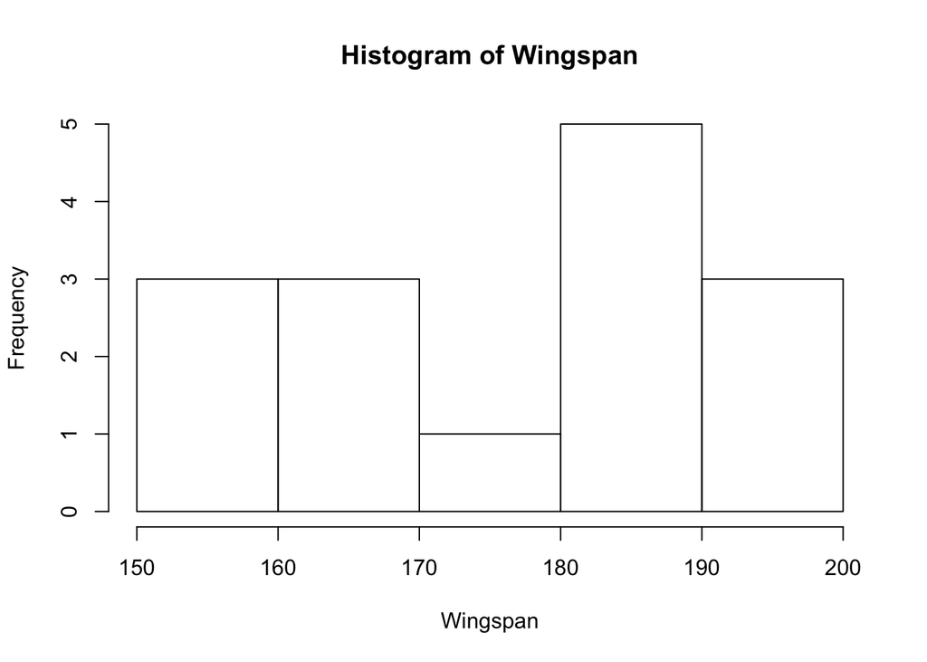

```r
hist(x = Wingspan)
```

```r
favstats(Wingspan)
```

```
##  min    Q1 median    Q3 max  mean       sd  n missing
##  153 165.5    181 184.5 198 176.8 14.27886 15       0
```

- The frequency of wingspan in the range of 170-180 is significantly lower than other ranges. Also, there are more people has wingspans in the range 180-190. Otherwise, the number of people have wingspans in other ranges is equal.
2. Distribution of Explanatory Variable. Construct an appropriate visual display of the distribution of the explanatory variable, describe its main features, and note anything unusual.

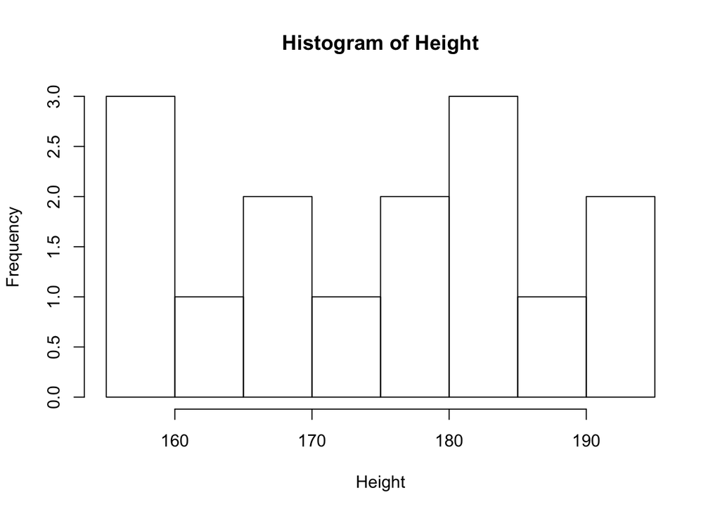

```r
hist(x = Height)
```

```r
favstats(Height)
```

```
##  min    Q1 median    Q3 max  mean       sd  n missing
##  157 165.5    178 184.5 192 175.4 12.07595 15       0
```

- The graph above shows the prequency of height.
- We can see that the amount of people that have height under 160cm is equal to the amount of people that have height ~ 180cm.
- It looks symmectric
3. Construct a scatterplot and describe the form, direction, and strength of the relationship between the two variables.

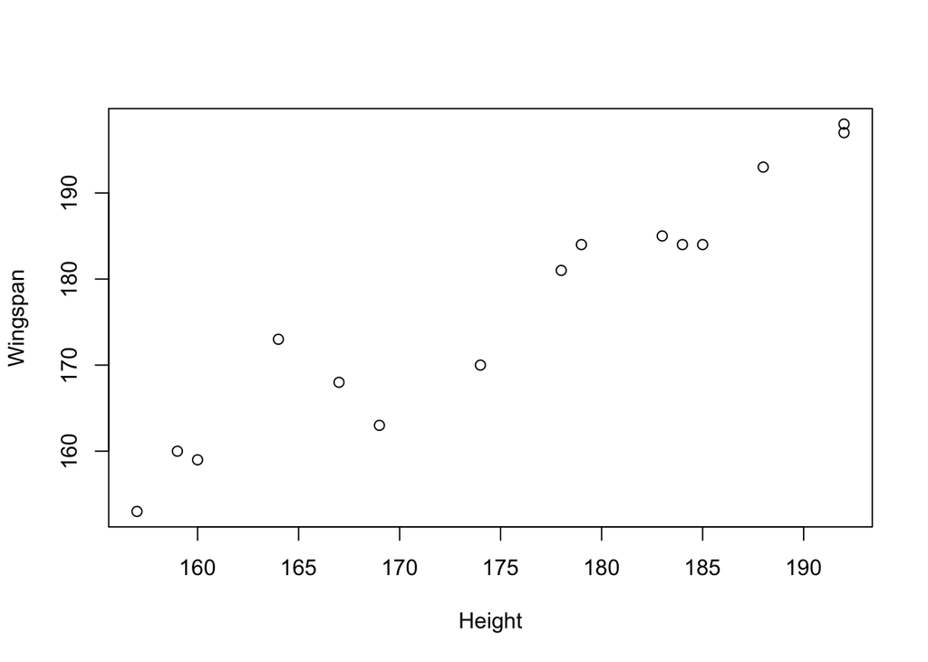

```r
plot(x = Height, y = Wingspan)
```

## D. Model Fitting

1. Obtain the equation of the least-squares regression line and draw it on the scatterplot.

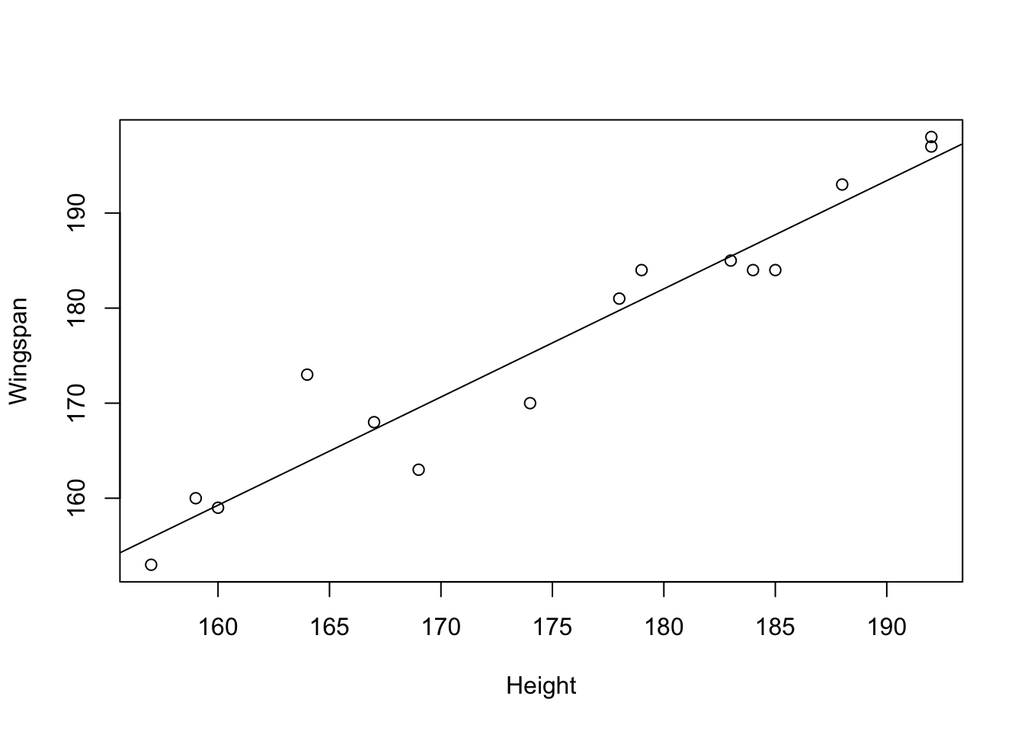

```r
reg = lm(Wingspan~Height)
plot(x = Height, y = Wingspan)
abline(reg = reg)
```

```r
summary(reg)
```

```
##
## Call:
## lm(formula = Wingspan ~ Height)
##
## Residuals:
##     Min      1Q  Median      3Q     Max
## -6.5141 -2.7217  0.7627  1.8630  9.1780
##
## Coefficients:
##              Estimate Std. Error t value Pr(>|t|)
## (Intercept) -22.87902   15.57994  -1.468    0.166
## Height        1.13842    0.08863  12.845  9.2e-09 ***
## ---
## Signif. codes:  0 '***' 0.001 '**' 0.01 '*' 0.05 '.' 0.1 ' ' 1
##
## Residual standard error: 4.005 on 13 degrees of freedom
## Multiple R-squared:  0.927,  Adjusted R-squared:  0.9213
## F-statistic:   165 on 1 and 13 DF,  p-value: 9.203e-09
```

2. Diagnostics: Conduct a residual analysis to verify the model assumptions.

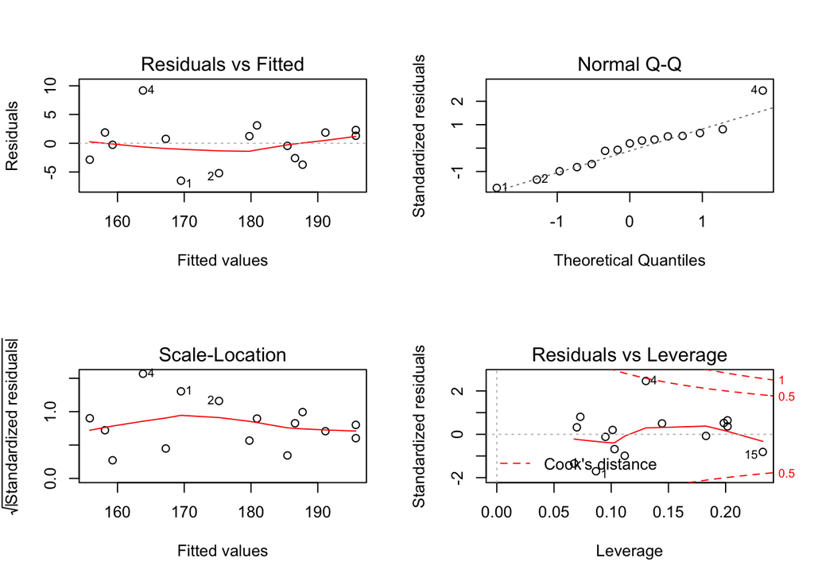

```r
par(mfrow=c(2,2))
plot(reg)
```

- The Normal Q-Q graph show that this model is a normal plot of residuals.
- The variance of residual is constant and the relationship is linear
3. Based on your plots in D.1 and 2, are any transformations necessary? If so, make those transformations and repeat your analysis.
- According to residual graphs above, we don’t need to make any further transformations.

## E. Inference

For significance tests, be sure to state the hypotheses and state your conclusion in context. You do not need to check the conditions because you already did that in D.2.

1. Construct a 95% confidence interval for the slope of the regression line. Interpret this CI in context.

```r
confint(reg)
```

```
##                   2.5 %    97.5 %
## (Intercept) -56.5374241 10.779391
## Height        0.9469488  1.329893
```

```r
cor.test(~Wingspan+Height)
```

```
##
##  Pearson's product-moment correlation
##
## data:  Wingspan and Height
## t = 12.845, df = 13, p-value = 9.203e-09
## alternative hypothesis: true correlation is not equal to 0
## 95 percent confidence interval:
##  0.8889619 0.9878452
## sample estimates:
##       cor
## 0.9627882
```

- The p-value is ~ 0.000
- There is 95 % confidence interval of [0.8889619, 0.9878452]
- The correlation coefficient is not 0.
3. ANOVA table:

```r
#Remember: the code is anova(model.lm), where model.lm is the model you fit in part D
anova(reg)
```

```
## Analysis of Variance Table
##
## Response: Wingspan
##           Df  Sum Sq Mean Sq F value    Pr(>F)
## Height     1 2645.92 2645.92  164.99 9.203e-09 ***
## Residuals 13  208.48   16.04
## ---
## Signif. codes:  0 '***' 0.001 '**' 0.01 '*' 0.05 '.' 0.1 ' ' 1
```

```r
#Code for confidence interval:
predict.lm(reg, data.frame("Height"=170), interval="confidence", level=0.9)
```

```
##        fit      lwr      upr
## 1 170.6525 168.6348 172.6703
```

```r
#Code for prediction interval:
predict.lm(reg, data.frame("Height"=170), interval="prediction", level=0.9)
```

```
##        fit      lwr      upr
## 1 170.6525 163.2791 178.0259
```

1. Do we want a prediction interval or a confidence interval?
- Confidence interval
2. Calculate the interval.
- From 168.6348 to 172.6703 (cm)
3. Interpret the interval.
- Our level of certainty is 90% about the true mean Wingspan of people whose Height is 170 cm (67") is within the interval between 168.6348 and 172.6703 assuming that the original random variable is normally distributed, and the samples are independent.
7. We want to calculate 90% interval for a person’s Wingspan when his/her Height is 170 cm (67").
1. Do we want a prediction interval or a confidence interval?
- Prediction interval
2. Will this interval be wider or narrower than the interval in #10b?
- The prediction interval is wider (has a larger SE) than the confidence interval.
3. Calculate the interval.
- From 163.2791 to 178.0259
4. Interpret the interval.
- Our level of certainty 90% that the true Wingspan of someone whose heigth is 170cm within the interval between 163.2791 and 178.0259 assuming that the original random variable is normally distributed, and the samples are independent.

### Conclusion:

Based on your analysis, Do people have heights that are in a linear relationship with their wingspan?

Yes, people do have heights that are in a linear relationship with their wingspan based on conditions for inferences, t-test, and f-test.

Do you concur with Vitruvius’ claim about the specific relationship between height and wingspan?